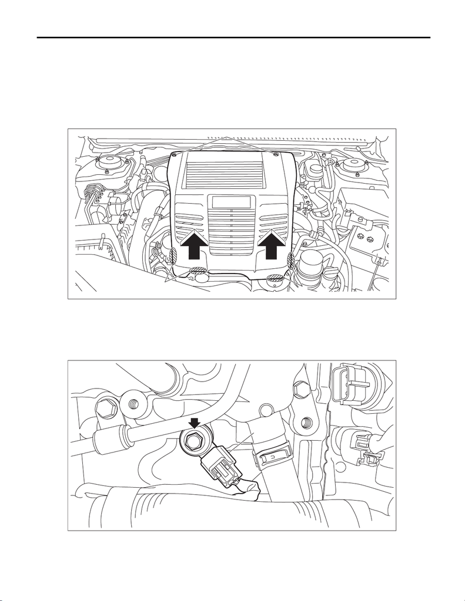

FU(w/o STI)-111

Knock Sensor

FUEL INJECTION (FUEL SYSTEMS)

17.Knock Sensor

A: REMOVAL

1. RH SIDE

1) Remove the collector cover.

(1) Remove the clips (A).

(2) Hold the shaded area (B) by hand and carefully pull the RH side (C) upward.

(3) Hold the shaded area (D) by hand and carefully pull the LH side (E) upward.

2) Disconnect the ground terminal from battery sensor. <Ref. to NT-5, BATTERY, NOTE, Note.>

3) Remove the intake manifold. <Ref. to FU(w/o STI)-18, REMOVAL, Intake Manifold.>

4) Remove the fuel pipe insulator No. 3. <Ref. to FU(w/o STI)-48, FUEL PIPE INSULATOR NO. 3, REMOV-

AL, Fuel Insulator.>

5) Disconnect the connector (A) from the knock sensor, and remove the knock sensor from the cylinder

block.

EX-03204

(A)

(B)

(C)

(E)

(D)

FU-07232

(A)

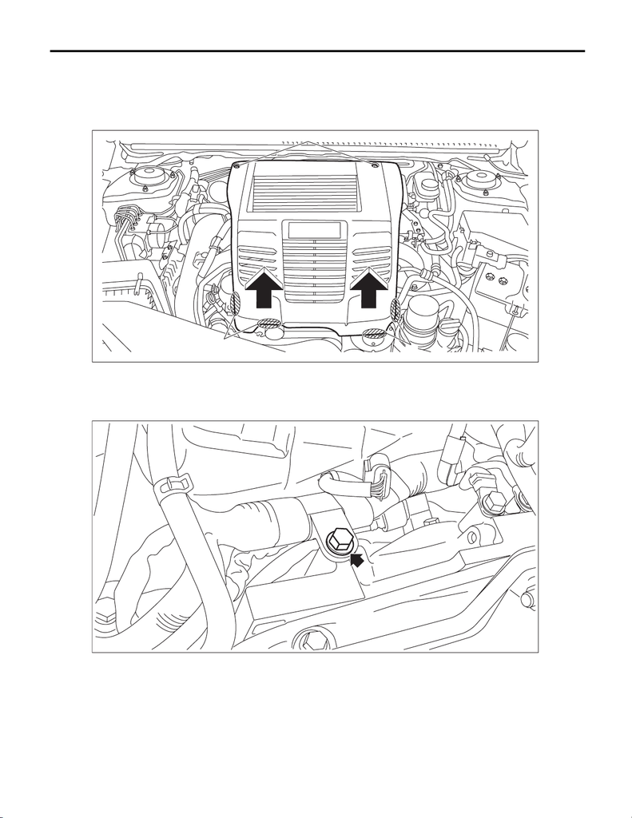

FU(w/o STI)-112

Knock Sensor

FUEL INJECTION (FUEL SYSTEMS)

2. LH SIDE

1) Remove the collector cover.

(1) Remove the clips (A).

(2) Hold the shaded area (B) by hand and carefully pull the RH side (C) upward.

(3) Hold the shaded area (D) by hand and carefully pull the LH side (E) upward.

2) Disconnect the ground terminal from battery sensor. <Ref. to NT-5, BATTERY, NOTE, Note.>

3) Remove the intercooler. <Ref. to IN(w/o STI)-38, REMOVAL, Intercooler.>

4) Remove the throttle body. <Ref. to FU(w/o STI)-15, REMOVAL, Throttle Body.>

5) Remove the bolts securing the engine harness.

EX-03204

(A)

(B)

(C)

(E)

(D)

FU-08485

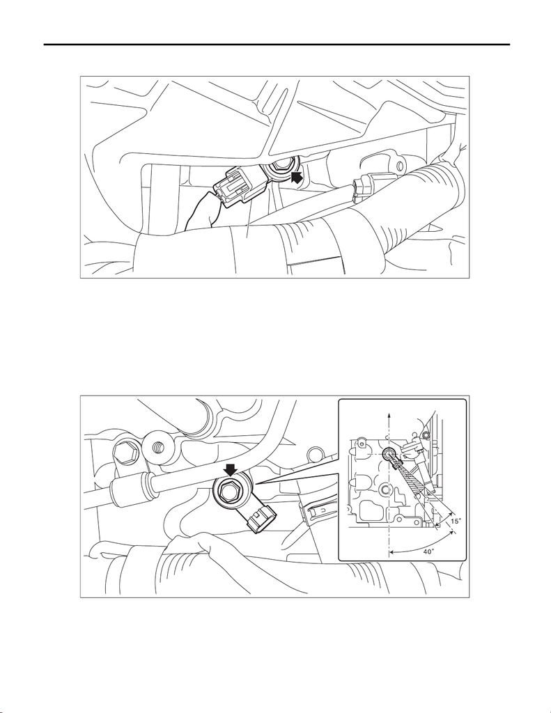

FU(w/o STI)-113

Knock Sensor

FUEL INJECTION (FUEL SYSTEMS)

6) Disconnect the connector (A) from the knock sensor, and remove the knock sensor from the cylinder

block.

B: INSTALLATION

1. RH SIDE

1) Install the knock sensor to the cylinder block.

NOTE:

The knock sensor should be installed so that the center of the connector is positioned at a 32.5 — 47.5° angle

relative to the rear of engine.

Tightening torque:

24 N·m (2.4 kgf-m, 17.7 ft-lb)

(A) Front of engine

FU-07230

(A)

FU-07935

(A)

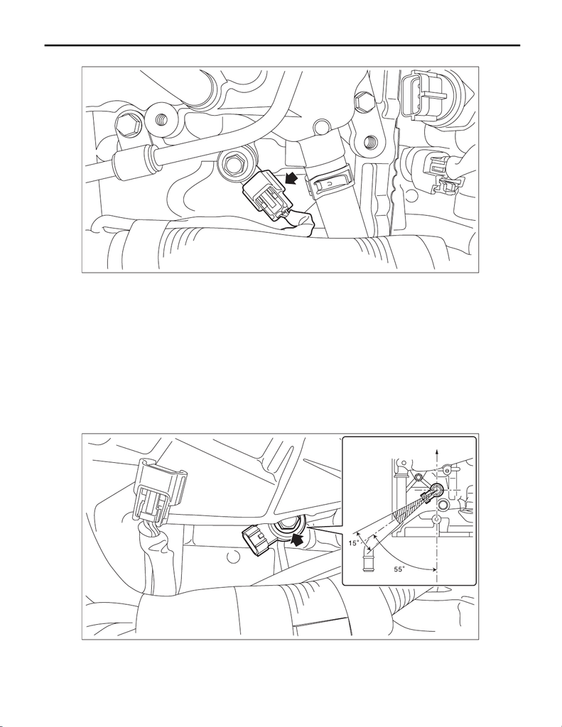

FU(w/o STI)-114

Knock Sensor

FUEL INJECTION (FUEL SYSTEMS)

2) Connect the connector to the knock sensor.

3) Install the fuel pipe insulator No. 3. <Ref. to FU(w/o STI)-50, FUEL PIPE INSULATOR NO. 3, INSTALLA-

TION, Fuel Insulator.>

4) Install the intake manifold. <Ref. to FU(w/o STI)-29, INSTALLATION, Intake Manifold.>

5) Connect the ground terminal to battery sensor. <Ref. to NT-5, BATTERY, NOTE, Note.>

6) Install the collector cover.

2. LH SIDE

1) Install the knock sensor to the cylinder block.

NOTE:

The knock sensor should be installed so that the center of the connector is positioned at a 47.5 — 62.5° angle

relative to the rear of engine.

Tightening torque:

24 N·m (2.4 kgf-m, 17.7 ft-lb)

(A) Front of engine

FU-07936

FU-07946

(A)

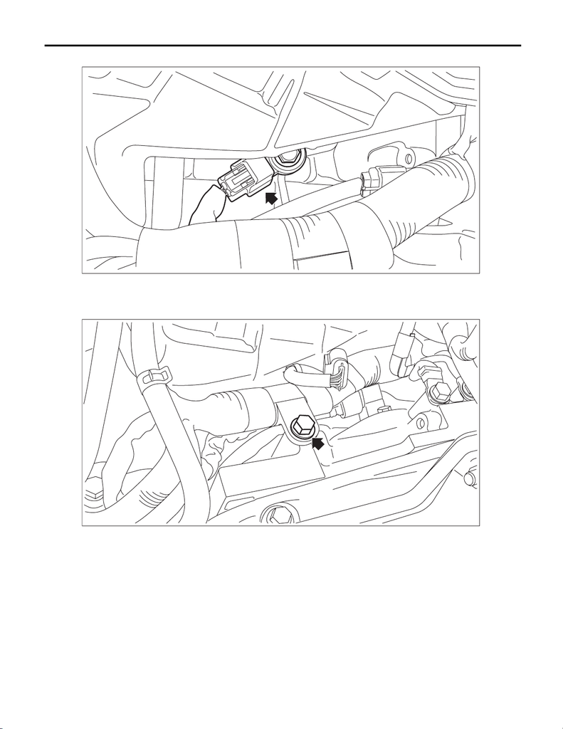

FU(w/o STI)-115

Knock Sensor

FUEL INJECTION (FUEL SYSTEMS)

2) Connect the connector to the knock sensor.

3) Install the bolts securing the engine harness.

Tightening torque:

19 N·m (1.9 kgf-m, 14.0 ft-lb)

4) Install the throttle body. <Ref. to FU(w/o STI)-16, INSTALLATION, Throttle Body.>

5) Install the intercooler. <Ref. to IN(w/o STI)-41, INSTALLATION, Intercooler.>

6) Connect the ground terminal to battery sensor. <Ref. to NT-5, BATTERY, NOTE, Note.>

7) Install the collector cover.

FU-07856

FU-08485

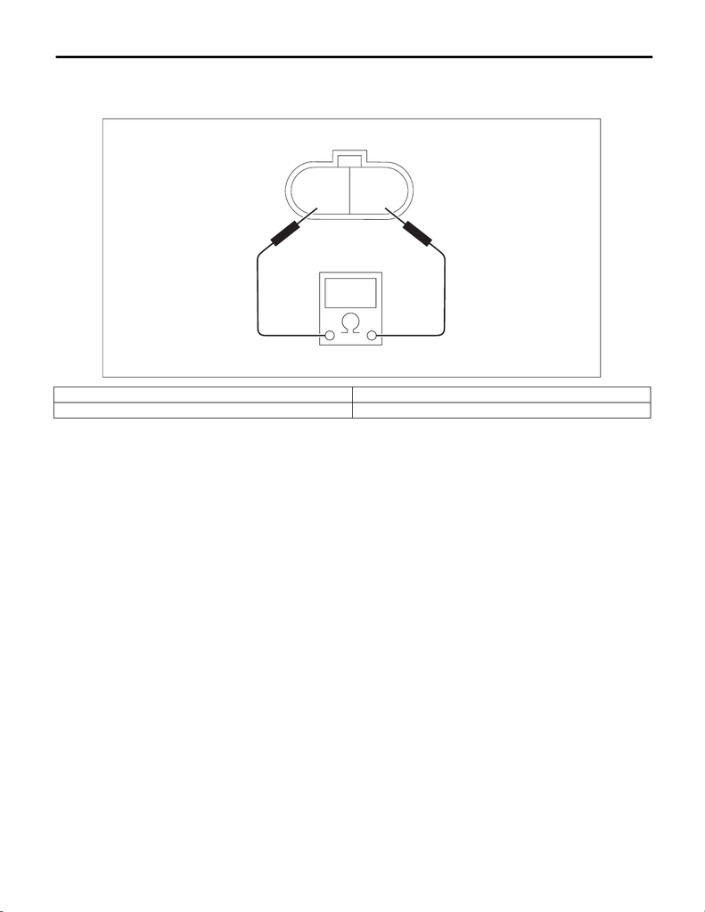

FU(w/o STI)-116

Knock Sensor

FUEL INJECTION (FUEL SYSTEMS)

C: INSPECTION

1) Check that the knock sensor has no deformation, cracks or other damages.

2) Measure the resistance between knock sensor terminals.

Terminal No. Standard

1 and 2 560±28 kΩ

EC-02799

21